# Risk Factor Analysis

## Outcome Variable

**Outcome Variable:** ever_stunted

## Predictor Variables

**Intervention Variable:** parity

**Adjustment Set:**

- arm
- W_mage
- meducyrs
- feducyrs
- hhwealth_quart
- W_mhtcm
- W_mwtkg
- W_mbmi
- vagbrth
- W_nrooms
- impsan
- delta_W_mage
- delta_meducyrs
- delta_feducyrs
- delta_hhwealth_quart
- delta_W_mhtcm
- delta_W_mwtkg
- delta_W_mbmi
- delta_vagbrth
- delta_W_nrooms
- delta_impsan

## Stratifying Variables

The analysis was stratified on these variable(s):

- agecat
- studyid
- country

## Data Summary

| agecat | studyid | country | parity | ever_stunted | n_cell | n |
| --- | --- | --- | --- | --- | --- | --- |
| 0-24 months | COHORTS | GUATEMALA | 1 | 0 | 54 | 1360 |
| 0-24 months | COHORTS | GUATEMALA | 1 | 1 | 159 | 1360 |
| 0-24 months | COHORTS | GUATEMALA | 2 | 0 | 44 | 1360 |
| 0-24 months | COHORTS | GUATEMALA | 2 | 1 | 148 | 1360 |
| 0-24 months | COHORTS | GUATEMALA | 3+ | 0 | 223 | 1360 |
| 0-24 months | COHORTS | GUATEMALA | 3+ | 1 | 732 | 1360 |
| 0-24 months | COHORTS | INDIA | 1 | 0 | 511 | 4630 |
| 0-24 months | COHORTS | INDIA | 1 | 1 | 301 | 4630 |
| 0-24 months | COHORTS | INDIA | 2 | 0 | 797 | 4630 |
| 0-24 months | COHORTS | INDIA | 2 | 1 | 388 | 4630 |
| 0-24 months | COHORTS | INDIA | 3+ | 0 | 1511 | 4630 |
| 0-24 months | COHORTS | INDIA | 3+ | 1 | 1122 | 4630 |
| 0-24 months | COHORTS | PHILIPPINES | 1 | 0 | 269 | 3058 |
| 0-24 months | COHORTS | PHILIPPINES | 1 | 1 | 409 | 3058 |
| 0-24 months | COHORTS | PHILIPPINES | 2 | 0 | 242 | 3058 |
| 0-24 months | COHORTS | PHILIPPINES | 2 | 1 | 448 | 3058 |
| 0-24 months | COHORTS | PHILIPPINES | 3+ | 0 | 448 | 3058 |
| 0-24 months | COHORTS | PHILIPPINES | 3+ | 1 | 1242 | 3058 |
| 0-24 months | GMS-Nepal | NEPAL | 1 | 0 | 74 | 698 |
| 0-24 months | GMS-Nepal | NEPAL | 1 | 1 | 137 | 698 |
| 0-24 months | GMS-Nepal | NEPAL | 2 | 0 | 74 | 698 |
| 0-24 months | GMS-Nepal | NEPAL | 2 | 1 | 107 | 698 |
| 0-24 months | GMS-Nepal | NEPAL | 3+ | 0 | 104 | 698 |
| 0-24 months | GMS-Nepal | NEPAL | 3+ | 1 | 202 | 698 |
| 0-24 months | JiVitA-3 | BANGLADESH | 1 | 0 | 4760 | 27227 |
| 0-24 months | JiVitA-3 | BANGLADESH | 1 | 1 | 5492 | 27227 |
| 0-24 months | JiVitA-3 | BANGLADESH | 2 | 0 | 4853 | 27227 |
| 0-24 months | JiVitA-3 | BANGLADESH | 2 | 1 | 4146 | 27227 |
| 0-24 months | JiVitA-3 | BANGLADESH | 3+ | 0 | 4128 | 27227 |
| 0-24 months | JiVitA-3 | BANGLADESH | 3+ | 1 | 3848 | 27227 |

[output cut: 168 more lines]

The following strata were considered:

- agecat: 0-24 months, studyid: COHORTS, country: GUATEMALA
- agecat: 0-24 months, studyid: COHORTS, country: INDIA
- agecat: 0-24 months, studyid: COHORTS, country: PHILIPPINES
- agecat: 0-24 months, studyid: GMS-Nepal, country: NEPAL
- agecat: 0-24 months, studyid: JiVitA-3, country: BANGLADESH
- agecat: 0-24 months, studyid: Keneba, country: GAMBIA
- agecat: 0-24 months, studyid: PROVIDE, country: BANGLADESH
- agecat: 0-24 months, studyid: SAS-CompFeed, country: INDIA
- agecat: 0-24 months, studyid: SAS-FoodSuppl, country: INDIA
- agecat: 0-24 months, studyid: TanzaniaChild2, country: TANZANIA, UNITED REPUBLIC OF
- agecat: 0-24 months, studyid: ZVITAMBO, country: ZIMBABWE
- agecat: 0-6 months, studyid: COHORTS, country: GUATEMALA
- agecat: 0-6 months, studyid: COHORTS, country: INDIA
- agecat: 0-6 months, studyid: COHORTS, country: PHILIPPINES
- agecat: 0-6 months, studyid: GMS-Nepal, country: NEPAL
- agecat: 0-6 months, studyid: JiVitA-3, country: BANGLADESH
- agecat: 0-6 months, studyid: Keneba, country: GAMBIA
- agecat: 0-6 months, studyid: PROVIDE, country: BANGLADESH
- agecat: 0-6 months, studyid: SAS-CompFeed, country: INDIA
- agecat: 0-6 months, studyid: SAS-FoodSuppl, country: INDIA
- agecat: 0-6 months, studyid: TanzaniaChild2, country: TANZANIA, UNITED REPUBLIC OF
- agecat: 0-6 months, studyid: ZVITAMBO, country: ZIMBABWE
- agecat: 6-24 months, studyid: COHORTS, country: GUATEMALA
- agecat: 6-24 months, studyid: COHORTS, country: INDIA
- agecat: 6-24 months, studyid: COHORTS, country: PHILIPPINES
- agecat: 6-24 months, studyid: GMS-Nepal, country: NEPAL
- agecat: 6-24 months, studyid: JiVitA-3, country: BANGLADESH
- agecat: 6-24 months, studyid: Keneba, country: GAMBIA
- agecat: 6-24 months, studyid: PROVIDE, country: BANGLADESH
- agecat: 6-24 months, studyid: SAS-CompFeed, country: INDIA
- agecat: 6-24 months, studyid: SAS-FoodSuppl, country: INDIA
- agecat: 6-24 months, studyid: TanzaniaChild2, country: TANZANIA, UNITED REPUBLIC OF
- agecat: 6-24 months, studyid: ZVITAMBO, country: ZIMBABWE

### Dropped Strata

Some strata were dropped due to rare outcomes:

- agecat: 6-24 months, studyid: SAS-FoodSuppl, country: INDIA

## Methods Detail

We’re interested in the causal parameters $E[Y_a]$ for all values of $a \in \mathcal{A}$. These parameters represent the mean outcome if, possibly contrary to fact, we intervened to set all units to have $A=a$. Under the randomization and positivity assumptions, these are identified by the statistical parameters $\psi_a=E_W[E_{Y|A,W}(Y|A=a,W)]$. In addition, we’re interested in the mean of $Y$, $E[Y]$ under no intervention (the observed mean). We will estimate these parameters by using SuperLearner to fit the relevant likelihood factors – $E_{Y|A,W}(Y|A=a,W)$ and $p(A=a|W)$, and then updating our likelihood fit using a joint TMLE.

For unadjusted analyses ($W=\{\}$), initial likelihoods were estimated using Lrnr_glm to estimate the simple $E(Y|A)$ and Lrnr_mean to estimate $p(A)$. For adjusted analyses, a small library containing Lrnr_glmnet, Lrnr_xgboost, and Lrnr_mean was used.

Having estimated these parameters, we will then use the delta method to estimate relative risks and attributable risks relative to a prespecified baseline level of $A$.

# Results Detail

## Results Plots

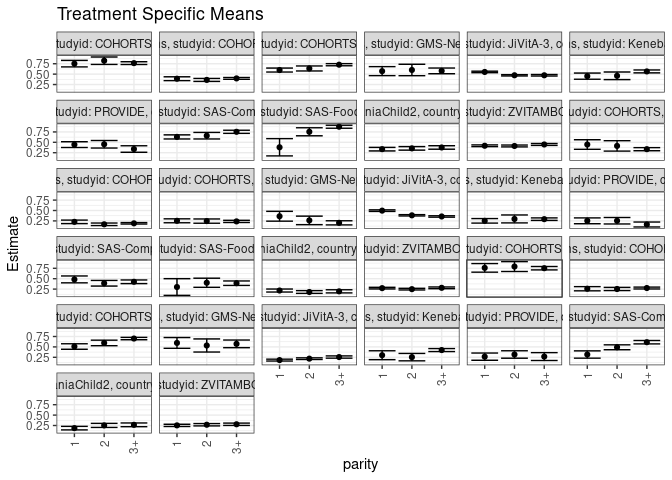

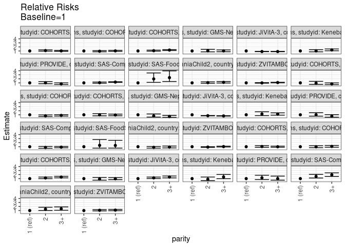

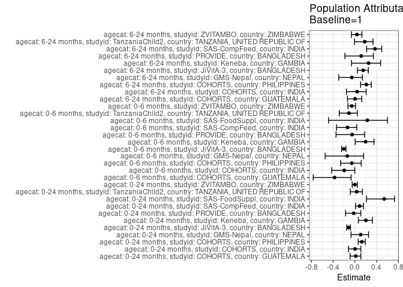

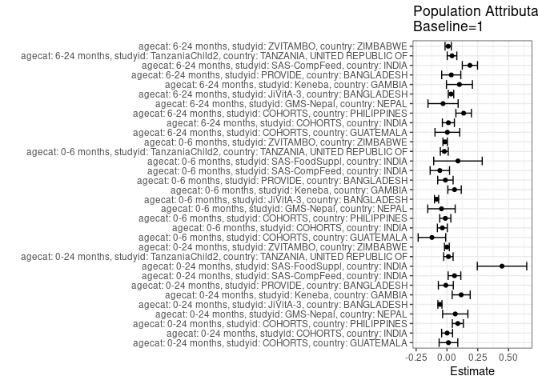

## Results Table

### Parameter: TSM

| agecat | studyid | country | intervention_level | baseline_level | estimate | ci_lower | ci_upper |
| --- | --- | --- | --- | --- | --- | --- | --- |
| 0-24 months | COHORTS | GUATEMALA | 1 | NA | 0.7516966 | 0.6735057 | 0.8298875 |
| 0-24 months | COHORTS | GUATEMALA | 2 | NA | 0.8227142 | 0.7333757 | 0.9120527 |
| 0-24 months | COHORTS | GUATEMALA | 3+ | NA | 0.7646106 | 0.7313600 | 0.7978612 |
| 0-24 months | COHORTS | INDIA | 1 | NA | 0.3897450 | 0.3434556 | 0.4360343 |
| 0-24 months | COHORTS | INDIA | 2 | NA | 0.3607223 | 0.3253708 | 0.3960739 |
| 0-24 months | COHORTS | INDIA | 3+ | NA | 0.3969142 | 0.3752545 | 0.4185739 |
| 0-24 months | COHORTS | PHILIPPINES | 1 | NA | 0.5979541 | 0.5501911 | 0.6457171 |
| 0-24 months | COHORTS | PHILIPPINES | 2 | NA | 0.6362284 | 0.5759002 | 0.6965566 |
| 0-24 months | COHORTS | PHILIPPINES | 3+ | NA | 0.7267105 | 0.7006467 | 0.7527744 |
| 0-24 months | GMS-Nepal | NEPAL | 1 | NA | 0.5715354 | 0.4633298 | 0.6797410 |
| 0-24 months | GMS-Nepal | NEPAL | 2 | NA | 0.5997877 | 0.4626409 | 0.7369345 |
| 0-24 months | GMS-Nepal | NEPAL | 3+ | NA | 0.5779347 | 0.5093320 | 0.6465374 |
| 0-24 months | JiVitA-3 | BANGLADESH | 1 | NA | 0.5522005 | 0.5339801 | 0.5704210 |
| 0-24 months | JiVitA-3 | BANGLADESH | 2 | NA | 0.4724473 | 0.4568048 | 0.4880899 |
| 0-24 months | JiVitA-3 | BANGLADESH | 3+ | NA | 0.4720824 | 0.4540195 | 0.4901453 |
| 0-24 months | Keneba | GAMBIA | 1 | NA | 0.4515942 | 0.3776468 | 0.5255415 |
| 0-24 months | Keneba | GAMBIA | 2 | NA | 0.4599346 | 0.3686167 | 0.5512525 |
| 0-24 months | Keneba | GAMBIA | 3+ | NA | 0.5649383 | 0.5302722 | 0.5996045 |
| 0-24 months | PROVIDE | BANGLADESH | 1 | NA | 0.4447737 | 0.3752579 | 0.5142894 |
| 0-24 months | PROVIDE | BANGLADESH | 2 | NA | 0.4534462 | 0.3626029 | 0.5442895 |
| 0-24 months | PROVIDE | BANGLADESH | 3+ | NA | 0.3386360 | 0.2605910 | 0.4166811 |
| 0-24 months | SAS-CompFeed | INDIA | 1 | NA | 0.6301501 | 0.5810231 | 0.6792771 |
| 0-24 months | SAS-CompFeed | INDIA | 2 | NA | 0.6588957 | 0.5803581 | 0.7374333 |
| 0-24 months | SAS-CompFeed | INDIA | 3+ | NA | 0.7529742 | 0.7149184 | 0.7910299 |
| 0-24 months | SAS-FoodSuppl | INDIA | 1 | NA | 0.3809524 | 0.1730038 | 0.5889009 |
| 0-24 months | SAS-FoodSuppl | INDIA | 2 | NA | 0.7532468 | 0.6568366 | 0.8496569 |
| 0-24 months | SAS-FoodSuppl | INDIA | 3+ | NA | 0.8750000 | 0.8387213 | 0.9112787 |
| 0-24 months | TanzaniaChild2 | TANZANIA, UNITED REPUBLIC OF | 1 | NA | 0.3352101 | 0.2927361 | 0.3776841 |
| 0-24 months | TanzaniaChild2 | TANZANIA, UNITED REPUBLIC OF | 2 | NA | 0.3546373 | 0.3119679 | 0.3973067 |
| 0-24 months | TanzaniaChild2 | TANZANIA, UNITED REPUBLIC OF | 3+ | NA | 0.3762178 | 0.3344746 | 0.4179610 |

[output cut: 66 more lines]

### Parameter: E(Y)

| agecat | studyid | country | intervention_level | baseline_level | estimate | ci_lower | ci_upper |
| --- | --- | --- | --- | --- | --- | --- | --- |
| 0-24 months | COHORTS | GUATEMALA | NA | NA | 0.7639706 | 0.7413939 | 0.7865473 |
| 0-24 months | COHORTS | INDIA | NA | NA | 0.3911447 | 0.3770865 | 0.4052029 |
| 0-24 months | COHORTS | PHILIPPINES | NA | NA | 0.6863963 | 0.6699497 | 0.7028430 |
| 0-24 months | GMS-Nepal | NEPAL | NA | NA | 0.6389685 | 0.6033115 | 0.6746254 |
| 0-24 months | JiVitA-3 | BANGLADESH | NA | NA | 0.4953171 | 0.4874955 | 0.5031388 |
| 0-24 months | Keneba | GAMBIA | NA | NA | 0.5673367 | 0.5455633 | 0.5891101 |
| 0-24 months | PROVIDE | BANGLADESH | NA | NA | 0.4357143 | 0.3989556 | 0.4724730 |
| 0-24 months | SAS-CompFeed | INDIA | NA | NA | 0.6914547 | 0.6510509 | 0.7318584 |
| 0-24 months | SAS-FoodSuppl | INDIA | NA | NA | 0.8277512 | 0.7915095 | 0.8639929 |
| 0-24 months | TanzaniaChild2 | TANZANIA, UNITED REPUBLIC OF | NA | NA | 0.3470513 | 0.3278294 | 0.3662733 |
| 0-24 months | ZVITAMBO | ZIMBABWE | NA | NA | 0.4171108 | 0.4089639 | 0.4252576 |
| 0-6 months | COHORTS | GUATEMALA | NA | NA | 0.3253896 | 0.2975756 | 0.3532035 |
| 0-6 months | COHORTS | INDIA | NA | NA | 0.1902526 | 0.1787489 | 0.2017563 |
| 0-6 months | COHORTS | PHILIPPINES | NA | NA | 0.2390451 | 0.2239262 | 0.2541640 |
| 0-6 months | GMS-Nepal | NEPAL | NA | NA | 0.3180516 | 0.2834770 | 0.3526261 |
| 0-6 months | JiVitA-3 | BANGLADESH | NA | NA | 0.4129818 | 0.4055453 | 0.4204184 |
| 0-6 months | Keneba | GAMBIA | NA | NA | 0.3135456 | 0.2924164 | 0.3346748 |
| 0-6 months | PROVIDE | BANGLADESH | NA | NA | 0.2400000 | 0.2083392 | 0.2716608 |
| 0-6 months | SAS-CompFeed | INDIA | NA | NA | 0.4254902 | 0.3977202 | 0.4532601 |
| 0-6 months | SAS-FoodSuppl | INDIA | NA | NA | 0.3894231 | 0.3425088 | 0.4363374 |
| 0-6 months | TanzaniaChild2 | TANZANIA, UNITED REPUBLIC OF | NA | NA | 0.1947391 | 0.1787488 | 0.2107293 |
| 0-6 months | ZVITAMBO | ZIMBABWE | NA | NA | 0.2586796 | 0.2514399 | 0.2659192 |
| 6-24 months | COHORTS | GUATEMALA | NA | NA | 0.7642458 | 0.7364214 | 0.7920702 |
| 6-24 months | COHORTS | INDIA | NA | NA | 0.2705750 | 0.2559548 | 0.2851951 |
| 6-24 months | COHORTS | PHILIPPINES | NA | NA | 0.6449788 | 0.6246093 | 0.6653483 |
| 6-24 months | GMS-Nepal | NEPAL | NA | NA | 0.5642317 | 0.5153938 | 0.6130696 |
| 6-24 months | JiVitA-3 | BANGLADESH | NA | NA | 0.2162394 | 0.2068628 | 0.2256160 |
| 6-24 months | Keneba | GAMBIA | NA | NA | 0.4014652 | 0.3754511 | 0.4274793 |
| 6-24 months | PROVIDE | BANGLADESH | NA | NA | 0.3004386 | 0.2583143 | 0.3425629 |
| 6-24 months | SAS-CompFeed | INDIA | NA | NA | 0.5030750 | 0.4588491 | 0.5473009 |
| 6-24 months | TanzaniaChild2 | TANZANIA, UNITED REPUBLIC OF | NA | NA | 0.2276474 | 0.2069456 | 0.2483493 |
| 6-24 months | ZVITAMBO | ZIMBABWE | NA | NA | 0.2629473 | 0.2535857 | 0.2723089 |

### Parameter: RR

| agecat | studyid | country | intervention_level | baseline_level | estimate | ci_lower | ci_upper |
| --- | --- | --- | --- | --- | --- | --- | --- |
| 0-24 months | COHORTS | GUATEMALA | 1 | 1 | 1.0000000 | 1.0000000 | 1.0000000 |
| 0-24 months | COHORTS | GUATEMALA | 2 | 1 | 1.0944764 | 0.9419627 | 1.2716837 |
| 0-24 months | COHORTS | GUATEMALA | 3+ | 1 | 1.0171798 | 0.9089919 | 1.1382442 |
| 0-24 months | COHORTS | INDIA | 1 | 1 | 1.0000000 | 1.0000000 | 1.0000000 |
| 0-24 months | COHORTS | INDIA | 2 | 1 | 0.9255343 | 0.7940687 | 1.0787654 |
| 0-24 months | COHORTS | INDIA | 3+ | 1 | 1.0183947 | 0.8942794 | 1.1597357 |
| 0-24 months | COHORTS | PHILIPPINES | 1 | 1 | 1.0000000 | 1.0000000 | 1.0000000 |
| 0-24 months | COHORTS | PHILIPPINES | 2 | 1 | 1.0640088 | 0.9406353 | 1.2035640 |
| 0-24 months | COHORTS | PHILIPPINES | 3+ | 1 | 1.2153283 | 1.1142155 | 1.3256170 |
| 0-24 months | GMS-Nepal | NEPAL | 1 | 1 | 1.0000000 | 1.0000000 | 1.0000000 |
| 0-24 months | GMS-Nepal | NEPAL | 2 | 1 | 1.0494323 | 0.7800210 | 1.4118957 |
| 0-24 months | GMS-Nepal | NEPAL | 3+ | 1 | 1.0111968 | 0.8083906 | 1.2648822 |
| 0-24 months | JiVitA-3 | BANGLADESH | 1 | 1 | 1.0000000 | 1.0000000 | 1.0000000 |
| 0-24 months | JiVitA-3 | BANGLADESH | 2 | 1 | 0.8555720 | 0.8183316 | 0.8945071 |
| 0-24 months | JiVitA-3 | BANGLADESH | 3+ | 1 | 0.8549111 | 0.8143180 | 0.8975278 |
| 0-24 months | Keneba | GAMBIA | 1 | 1 | 1.0000000 | 1.0000000 | 1.0000000 |
| 0-24 months | Keneba | GAMBIA | 2 | 1 | 1.0184690 | 0.7877036 | 1.3168392 |
| 0-24 months | Keneba | GAMBIA | 3+ | 1 | 1.2509867 | 1.0505384 | 1.4896816 |
| 0-24 months | PROVIDE | BANGLADESH | 1 | 1 | 1.0000000 | 1.0000000 | 1.0000000 |
| 0-24 months | PROVIDE | BANGLADESH | 2 | 1 | 1.0194988 | 0.7922005 | 1.3120135 |
| 0-24 months | PROVIDE | BANGLADESH | 3+ | 1 | 0.7613671 | 0.5781958 | 1.0025666 |
| 0-24 months | SAS-CompFeed | INDIA | 1 | 1 | 1.0000000 | 1.0000000 | 1.0000000 |
| 0-24 months | SAS-CompFeed | INDIA | 2 | 1 | 1.0456171 | 0.9109082 | 1.2002473 |
| 0-24 months | SAS-CompFeed | INDIA | 3+ | 1 | 1.1949125 | 1.1082074 | 1.2884013 |
| 0-24 months | SAS-FoodSuppl | INDIA | 1 | 1 | 1.0000000 | 1.0000000 | 1.0000000 |
| 0-24 months | SAS-FoodSuppl | INDIA | 2 | 1 | 1.9772727 | 1.1286797 | 3.4638767 |
| 0-24 months | SAS-FoodSuppl | INDIA | 3+ | 1 | 2.2968750 | 1.3285819 | 3.9708764 |
| 0-24 months | TanzaniaChild2 | TANZANIA, UNITED REPUBLIC OF | 1 | 1 | 1.0000000 | 1.0000000 | 1.0000000 |
| 0-24 months | TanzaniaChild2 | TANZANIA, UNITED REPUBLIC OF | 2 | 1 | 1.0579555 | 0.8888778 | 1.2591942 |
| 0-24 months | TanzaniaChild2 | TANZANIA, UNITED REPUBLIC OF | 3+ | 1 | 1.1223344 | 0.9487689 | 1.3276515 |

[output cut: 66 more lines]

### Parameter: PAR

| agecat | studyid | country | intervention_level | baseline_level | estimate | ci_lower | ci_upper |
| --- | --- | --- | --- | --- | --- | --- | --- |
| 0-24 months | COHORTS | GUATEMALA | 1 | NA | 0.0122740 | -0.0634866 | 0.0880345 |
| 0-24 months | COHORTS | INDIA | 1 | NA | 0.0013998 | -0.0428975 | 0.0456970 |
| 0-24 months | COHORTS | PHILIPPINES | 1 | NA | 0.0884423 | 0.0437089 | 0.1331756 |
| 0-24 months | GMS-Nepal | NEPAL | 1 | NA | 0.0674331 | -0.0350058 | 0.1698720 |
| 0-24 months | JiVitA-3 | BANGLADESH | 1 | NA | -0.0568834 | -0.0735438 | -0.0402230 |
| 0-24 months | Keneba | GAMBIA | 1 | NA | 0.1157425 | 0.0427195 | 0.1887656 |
| 0-24 months | PROVIDE | BANGLADESH | 1 | NA | -0.0090594 | -0.0697889 | 0.0516701 |
| 0-24 months | SAS-CompFeed | INDIA | 1 | NA | 0.0613046 | 0.0100120 | 0.1125972 |
| 0-24 months | SAS-FoodSuppl | INDIA | 1 | NA | 0.4467988 | 0.2462717 | 0.6473259 |
| 0-24 months | TanzaniaChild2 | TANZANIA, UNITED REPUBLIC OF | 1 | NA | 0.0118413 | -0.0264178 | 0.0501004 |
| 0-24 months | ZVITAMBO | ZIMBABWE | 1 | NA | -0.0004291 | -0.0199179 | 0.0190596 |
| 0-6 months | COHORTS | GUATEMALA | 1 | NA | -0.1217925 | -0.2334585 | -0.0101264 |
| 0-6 months | COHORTS | INDIA | 1 | NA | -0.0372283 | -0.0774725 | 0.0030158 |
| 0-6 months | COHORTS | PHILIPPINES | 1 | NA | -0.0132669 | -0.0582999 | 0.0317661 |
| 0-6 months | GMS-Nepal | NEPAL | 1 | NA | -0.0442698 | -0.1554015 | 0.0668618 |
| 0-6 months | JiVitA-3 | BANGLADESH | 1 | NA | -0.0840483 | -0.1008649 | -0.0672318 |
| 0-6 months | Keneba | GAMBIA | 1 | NA | 0.0618477 | 0.0074629 | 0.1162326 |
| 0-6 months | PROVIDE | BANGLADESH | 1 | NA | -0.0123060 | -0.0747367 | 0.0501246 |
| 0-6 months | SAS-CompFeed | INDIA | 1 | NA | -0.0575640 | -0.1362340 | 0.0211060 |
| 0-6 months | SAS-FoodSuppl | INDIA | 1 | NA | 0.0894231 | -0.1074162 | 0.2862624 |
| 0-6 months | TanzaniaChild2 | TANZANIA, UNITED REPUBLIC OF | 1 | NA | -0.0212210 | -0.0533720 | 0.0109299 |
| 0-6 months | ZVITAMBO | ZIMBABWE | 1 | NA | -0.0145848 | -0.0324921 | 0.0033225 |
| 6-24 months | COHORTS | GUATEMALA | 1 | NA | 0.0033018 | -0.0970192 | 0.1036227 |
| 6-24 months | COHORTS | INDIA | 1 | NA | 0.0117190 | -0.0370960 | 0.0605340 |
| 6-24 months | COHORTS | PHILIPPINES | 1 | NA | 0.1355942 | 0.0726327 | 0.1985557 |
| 6-24 months | GMS-Nepal | NEPAL | 1 | NA | -0.0314919 | -0.1538309 | 0.0908470 |
| 6-24 months | JiVitA-3 | BANGLADESH | 1 | NA | 0.0332425 | 0.0114386 | 0.0550465 |
| 6-24 months | Keneba | GAMBIA | 1 | NA | 0.1013924 | -0.0040857 | 0.2068705 |
| 6-24 months | PROVIDE | BANGLADESH | 1 | NA | 0.0350424 | -0.0425434 | 0.1126281 |
| 6-24 months | SAS-CompFeed | INDIA | 1 | NA | 0.1863274 | 0.1246047 | 0.2480501 |
| 6-24 months | TanzaniaChild2 | TANZANIA, UNITED REPUBLIC OF | 1 | NA | 0.0412886 | 0.0024158 | 0.0801614 |
| 6-24 months | ZVITAMBO | ZIMBABWE | 1 | NA | 0.0100198 | -0.0152706 | 0.0353101 |

### Parameter: PAF

| agecat | studyid | country | intervention_level | baseline_level | estimate | ci_lower | ci_upper |
| --- | --- | --- | --- | --- | --- | --- | --- |
| 0-24 months | COHORTS | GUATEMALA | 1 | NA | 0.0160660 | -0.0882508 | 0.1103833 |
| 0-24 months | COHORTS | INDIA | 1 | NA | 0.0035786 | -0.1163565 | 0.1106285 |
| 0-24 months | COHORTS | PHILIPPINES | 1 | NA | 0.1288501 | 0.0610784 | 0.1917301 |
| 0-24 months | GMS-Nepal | NEPAL | 1 | NA | 0.1055343 | -0.0701252 | 0.2523596 |
| 0-24 months | JiVitA-3 | BANGLADESH | 1 | NA | -0.1148424 | -0.1490896 | -0.0816159 |
| 0-24 months | Keneba | GAMBIA | 1 | NA | 0.2040103 | 0.0650079 | 0.3223476 |
| 0-24 months | PROVIDE | BANGLADESH | 1 | NA | -0.0207921 | -0.1702406 | 0.1095708 |
| 0-24 months | SAS-CompFeed | INDIA | 1 | NA | 0.0886603 | 0.0137205 | 0.1579061 |
| 0-24 months | SAS-FoodSuppl | INDIA | 1 | NA | 0.5397743 | 0.2142753 | 0.7304301 |
| 0-24 months | TanzaniaChild2 | TANZANIA, UNITED REPUBLIC OF | 1 | NA | 0.0341197 | -0.0826344 | 0.1382826 |
| 0-24 months | ZVITAMBO | ZIMBABWE | 1 | NA | -0.0010288 | -0.0488601 | 0.0446211 |
| 0-6 months | COHORTS | GUATEMALA | 1 | NA | -0.3742975 | -0.7660626 | -0.0694375 |
| 0-6 months | COHORTS | INDIA | 1 | NA | -0.1956783 | -0.4271999 | -0.0017143 |
| 0-6 months | COHORTS | PHILIPPINES | 1 | NA | -0.0554995 | -0.2618744 | 0.1171236 |
| 0-6 months | GMS-Nepal | NEPAL | 1 | NA | -0.1391908 | -0.5476126 | 0.1614467 |
| 0-6 months | JiVitA-3 | BANGLADESH | 1 | NA | -0.2035158 | -0.2450683 | -0.1633501 |
| 0-6 months | Keneba | GAMBIA | 1 | NA | 0.1972527 | 0.0059871 | 0.3517155 |
| 0-6 months | PROVIDE | BANGLADESH | 1 | NA | -0.0512752 | -0.3465027 | 0.1792222 |
| 0-6 months | SAS-CompFeed | INDIA | 1 | NA | -0.1352887 | -0.3366544 | 0.0357414 |
| 0-6 months | SAS-FoodSuppl | INDIA | 1 | NA | 0.2296296 | -0.4847259 | 0.6002828 |
| 0-6 months | TanzaniaChild2 | TANZANIA, UNITED REPUBLIC OF | 1 | NA | -0.1089716 | -0.2870718 | 0.0444837 |
| 0-6 months | ZVITAMBO | ZIMBABWE | 1 | NA | -0.0563818 | -0.1279569 | 0.0106515 |
| 6-24 months | COHORTS | GUATEMALA | 1 | NA | 0.0043203 | -0.1359885 | 0.1272992 |
| 6-24 months | COHORTS | INDIA | 1 | NA | 0.0433114 | -0.1551824 | 0.2076982 |
| 6-24 months | COHORTS | PHILIPPINES | 1 | NA | 0.2102305 | 0.1059728 | 0.3023301 |
| 6-24 months | GMS-Nepal | NEPAL | 1 | NA | -0.0558138 | -0.2968598 | 0.1404291 |
| 6-24 months | JiVitA-3 | BANGLADESH | 1 | NA | 0.1537302 | 0.0474732 | 0.2481340 |
| 6-24 months | Keneba | GAMBIA | 1 | NA | 0.2525560 | -0.0613056 | 0.4735988 |
| 6-24 months | PROVIDE | BANGLADESH | 1 | NA | 0.1166373 | -0.1831545 | 0.3404669 |
| 6-24 months | SAS-CompFeed | INDIA | 1 | NA | 0.3703769 | 0.2165570 | 0.4939960 |
| 6-24 months | TanzaniaChild2 | TANZANIA, UNITED REPUBLIC OF | 1 | NA | 0.1813709 | -0.0077021 | 0.3349686 |
| 6-24 months | ZVITAMBO | ZIMBABWE | 1 | NA | 0.0381056 | -0.0630258 | 0.1296158 |